# Biodiversity of macrozoobenthic communities in Sozopol Bay

Preliminary experiment - 2012

2018-01-29

Decided to move all 2012 analyses to their own notebook, even if it’s kind of clumsy to jump back and forth, because there are way too many workspace objects otherwise.  
This notebook depends heavily on functions, objects & workflow developed for the other, primary experiments. It shouldn’t be too much of a problem if it is run **after** the other analyses; I’ll make an effort to make it as independent as possible.

Setup.

Define the working subdirectories.

```r
## print the working directory, just to be on the safe side
paste("You are here: ", getwd())

data.dir <- "data"    # input data files
functions.dir <- "R"  # functions & scripts
save.dir <- "output"  # clean data, output from models & more complex calculations
figures.dir <- "figs" # plots & figures
```

Import the necessary libraries.

```r
library(here)
library(vegan)
library(tidyverse)
library(viridis)
```

Import functions.

```r
source(here(functions.dir, "import_data.R"))
```

Organize some commonly-used ggplot2 modifications into a more convenient (and less repetitive) format.

```r
## ggplot settings & things that I keep reusing
# ggplot_theme <- list(
#   theme_bw(),
#   theme(element_text(family = "Times"))
# )
## always use black-and-white theme
theme_set(theme_bw())
## helper to adjust ggplot text size & avoid repetitions
text_size <- function(text.x = NULL,
                      text.y = NULL,
                      title.x = NULL,
                      title.y = NULL,
                      legend.text = NULL,
                      legend.title = NULL,
                      strip.x = NULL,
                      strip.y = NULL) {
  theme(axis.text.x = element_text(size = text.x),
        axis.text.y = element_text(size = text.y),
        axis.title.x = element_text(size = title.x),
        axis.title.y = element_text(size = title.y),
        legend.text = element_text(size = legend.text),
        legend.title = element_text(size = legend.title),
        strip.text.x = element_text(size = strip.x),
        strip.text.y = element_text(size = strip.y)
        )
  }
```

#### Macrozoobenthic communities in the seagrass and sand bottoms of Sozopol Bay (2012)

For this experiment, 3 seagrass sites in Sozpol Bay were chosen (Konski, Ribka, Gradina), with 2 stations within each (total = 6 stations).  
At each station, 4 samples were taken within the seagrass bed, and another 4 - outside it, in the bare sand bottom.  
The purpose was to compare the macrobenthic community composition & structure at the level of the sites, as well as between sites, in the 2 types of habitat (sand and seagrass).

Import the zoobenthic abundance & biomass data.

```r
## import & check the abundance data. Dimensions should be 48 x 205 (5 metadata + 200 species columns); all species columns should be numeric.
(zoo.abnd.2012 <- import_zoo_data(data.dir = data.dir,
                                  zoo.data = "zoo_abnd_2012_orig.csv",
                                  meta.labels = c("station", "month", "year", "habitat", "replicate")))
```

|  | station | month | year | habitat | replicate | Abra alba | Abra prismatica | Abra segmentum | Abra sp. | Acanthocardia tuberculata | Acari | Actiniaria | Alitta succinea | Ampelisca diadema | Ampharetidae | Amphibalanus improvisus | Amphipoda | Amphitritides gracilis | Ampithoe sp. | Anadara kagoshimensis | Aonides paucibranchiata | Apherusa bispinosa | Apseudopsis ostroumovi | Aricidea claudiae | Bathyporeia guilliamsoniana | Bittium reticulatum | Bivalvia undet. | Bodotria arenosa | Brachynotus sexdentatus | … |
| --- | --- | --- | --- | --- | --- | --- | --- | --- | --- | --- | --- | --- | --- | --- | --- | --- | --- | --- | --- | --- | --- | --- | --- | --- | --- | --- | --- | --- | --- | --- |
| 1 | Gradina1 | 7 | 2012 | S | a | 0 | 0 | 0 | 0 | 0 | 0 | 0 | 0 | 0 | 0 | 0 | 0 | 0 | 0 | 0 | 0 | 0 | 0 | 0 | 0 | 4 | 0 | 0 | 0 | … |
| 2 | Gradina1 | 7 | 2012 | S | b | 0 | 0 | 0 | 0 | 0 | 0 | 0 | 0 | 0 | 0 | 0 | 0 | 0 | 0 | 0 | 0 | 0 | 0 | 0 | 0 | 0 | 0 | 0 | 0 | … |
| 3 | Gradina1 | 7 | 2012 | S | c | 0 | 0 | 0 | 0 | 0 | 0 | 0 | 0 | 0 | 0 | 0 | 0 | 0 | 0 | 0 | 0 | 0 | 0 | 0 | 0 | 0 | 0 | 0 | 0 | … |
| 4 | Gradina1 | 7 | 2012 | S | d | 0 | 0 | 0 | 0 | 0 | 0 | 0 | 0 | 0 | 0 | 0 | 0 | 0 | 0 | 0 | 0 | 0 | 0 | 0 | 0 | 0 | 0 | 0 | 0 | … |
| 5 | Gradina1 | 7 | 2012 | Z | a | 0 | 0 | 0 | 0 | 0 | 0 | 0 | 0 | 0 | 0 | 0 | 0 | 0 | 0 | 0 | 0 | 0 | 0 | 0 | 0 | 55 | 0 | 0 | 0 | … |
| 6 | Gradina1 | 7 | 2012 | Z | b | 0 | 0 | 0 | 0 | 0 | 0 | 0 | 0 | 0 | 0 | 0 | 0 | 0 | 0 | 0 | 0 | 0 | 0 | 0 | 0 | 66 | 0 | 0 | 0 | … |
| 7 | Gradina1 | 7 | 2012 | Z | c | 0 | 1 | 0 | 0 | 0 | 0 | 0 | 0 | 0 | 0 | 0 | 0 | 0 | 0 | 0 | 0 | 0 | 0 | 0 | 0 | 54 | 0 | 0 | 0 | … |
| 8 | Gradina1 | 7 | 2012 | Z | d | 0 | 0 | 0 | 0 | 0 | 0 | 0 | 0 | 0 | 0 | 0 | 0 | 0 | 0 | 0 | 0 | 0 | 0 | 0 | 0 | 39 | 0 | 0 | 0 | … |
| 9 | Gradina2 | 7 | 2012 | S | a | 0 | 0 | 1 | 0 | 0 | 0 | 0 | 0 | 0 | 0 | 0 | 0 | 0 | 0 | 0 | 0 | 0 | 0 | 0 | 0 | 1 | 0 | 0 | 0 | … |
| 10 | Gradina2 | 7 | 2012 | S | b | 0 | 1 | 0 | 0 | 0 | 0 | 0 | 0 | 0 | 0 | 0 | 0 | 0 | 0 | 0 | 0 | 0 | 0 | 0 | 0 | 3 | 0 | 0 | 0 | … |

[output cut: 38 more lines]

Convert the month and year back to numeric, then arrange the data frame - by station (first converting to factor), then year and month, then habitat. In this experiment, there were 2 habitats - sand and seagrass.

```r
(zoo.abnd.2012 <- zoo.abnd.2012 %>%
   mutate(year = as.numeric(year),
          month = as.numeric(month),
          station = factor(station, levels = c("Konski1", "Konski2", "Ribka1", "Ribka2", "Gradina1", "Gradina2"))) %>%
   arrange(habitat, station)
)
```

| station | month | year | habitat | replicate | Abra alba | Abra prismatica | Abra segmentum | Abra sp. | Acanthocardia tuberculata | Acari | Actiniaria | Alitta succinea | Ampelisca diadema | Ampharetidae | Amphibalanus improvisus | Amphipoda | Amphitritides gracilis | Ampithoe sp. | Anadara kagoshimensis | Aonides paucibranchiata | Apherusa bispinosa | Apseudopsis ostroumovi | Aricidea claudiae | Bathyporeia guilliamsoniana | Bittium reticulatum | Bivalvia undet. | Bodotria arenosa | Brachynotus sexdentatus | Brachystomia scalaris | … |
| --- | --- | --- | --- | --- | --- | --- | --- | --- | --- | --- | --- | --- | --- | --- | --- | --- | --- | --- | --- | --- | --- | --- | --- | --- | --- | --- | --- | --- | --- | --- |
| Konski1 | 7 | 2012 | S | a | 0 | 0 | 4 | 0 | 0 | 0 | 0 | 0 | 5 | 0 | 0 | 0 | 0 | 0 | 0 | 0 | 0 | 0 | 0 | 0 | 16 | 0 | 0 | 0 | 0 | … |
| Konski1 | 7 | 2012 | S | b | 0 | 0 | 0 | 0 | 0 | 0 | 0 | 0 | 1 | 0 | 0 | 2 | 0 | 0 | 0 | 0 | 0 | 0 | 0 | 0 | 20 | 0 | 0 | 0 | 0 | … |
| Konski1 | 7 | 2012 | S | c | 0 | 0 | 4 | 0 | 0 | 0 | 0 | 0 | 0 | 0 | 0 | 0 | 0 | 0 | 0 | 0 | 0 | 0 | 0 | 0 | 8 | 0 | 0 | 0 | 0 | … |
| Konski1 | 7 | 2012 | S | d | 0 | 0 | 0 | 0 | 0 | 0 | 0 | 0 | 2 | 0 | 0 | 1 | 0 | 0 | 0 | 0 | 0 | 0 | 0 | 0 | 32 | 0 | 0 | 0 | 0 | … |
| Konski2 | 7 | 2012 | S | a | 0 | 0 | 0 | 0 | 0 | 0 | 0 | 0 | 0 | 1 | 0 | 0 | 0 | 0 | 0 | 0 | 0 | 0 | 0 | 0 | 80 | 0 | 0 | 0 | 0 | … |
| Konski2 | 7 | 2012 | S | b | 0 | 0 | 0 | 0 | 0 | 0 | 0 | 0 | 0 | 0 | 0 | 0 | 0 | 0 | 0 | 0 | 0 | 0 | 0 | 0 | 12 | 0 | 0 | 0 | 0 | … |
| Konski2 | 7 | 2012 | S | c | 0 | 0 | 0 | 0 | 0 | 0 | 0 | 0 | 0 | 0 | 0 | 1 | 0 | 0 | 0 | 0 | 0 | 0 | 0 | 0 | 20 | 0 | 0 | 0 | 0 | … |
| Konski2 | 7 | 2012 | S | d | 0 | 4 | 0 | 0 | 0 | 0 | 0 | 0 | 0 | 1 | 0 | 0 | 0 | 0 | 0 | 0 | 0 | 0 | 0 | 0 | 16 | 0 | 0 | 0 | 0 | … |
| Ribka1 | 7 | 2012 | S | a | 0 | 2 | 0 | 0 | 0 | 0 | 0 | 0 | 0 | 0 | 0 | 0 | 0 | 0 | 0 | 0 | 0 | 0 | 0 | 0 | 3 | 0 | 0 | 0 | 0 | … |
| Ribka1 | 7 | 2012 | S | b | 0 | 0 | 0 | 0 | 0 | 0 | 0 | 0 | 0 | 0 | 6 | 0 | 0 | 0 | 0 | 0 | 0 | 0 | 0 | 0 | 0 | 0 | 0 | 0 | 0 | … |

[output cut: 38 more lines]

Add the site & arrange.

```r
(zoo.abnd.2012 <- zoo.abnd.2012 %>%
   # match 0+ characters at the beginning of the given string which are not digits - because the names of the stations here consist of site + station number.
   mutate(site = str_extract(station, "[^\\d]+")) %>%
   mutate(site = factor(site, levels = c("Konski", "Ribka", "Gradina"))) %>%
  # rearrange to place site at the beginning of the data frame
  select(site, everything()) %>%
  arrange(habitat, site, station)
)
```

| site | station | month | year | habitat | replicate | Abra alba | Abra prismatica | Abra segmentum | Abra sp. | Acanthocardia tuberculata | Acari | Actiniaria | Alitta succinea | Ampelisca diadema | Ampharetidae | Amphibalanus improvisus | Amphipoda | Amphitritides gracilis | Ampithoe sp. | Anadara kagoshimensis | Aonides paucibranchiata | Apherusa bispinosa | Apseudopsis ostroumovi | Aricidea claudiae | Bathyporeia guilliamsoniana | Bittium reticulatum | Bivalvia undet. | Bodotria arenosa | Brachynotus sexdentatus | … |
| --- | --- | --- | --- | --- | --- | --- | --- | --- | --- | --- | --- | --- | --- | --- | --- | --- | --- | --- | --- | --- | --- | --- | --- | --- | --- | --- | --- | --- | --- | --- |
| Konski | Konski1 | 7 | 2012 | S | a | 0 | 0 | 4 | 0 | 0 | 0 | 0 | 0 | 5 | 0 | 0 | 0 | 0 | 0 | 0 | 0 | 0 | 0 | 0 | 0 | 16 | 0 | 0 | 0 | … |
| Konski | Konski1 | 7 | 2012 | S | b | 0 | 0 | 0 | 0 | 0 | 0 | 0 | 0 | 1 | 0 | 0 | 2 | 0 | 0 | 0 | 0 | 0 | 0 | 0 | 0 | 20 | 0 | 0 | 0 | … |
| Konski | Konski1 | 7 | 2012 | S | c | 0 | 0 | 4 | 0 | 0 | 0 | 0 | 0 | 0 | 0 | 0 | 0 | 0 | 0 | 0 | 0 | 0 | 0 | 0 | 0 | 8 | 0 | 0 | 0 | … |
| Konski | Konski1 | 7 | 2012 | S | d | 0 | 0 | 0 | 0 | 0 | 0 | 0 | 0 | 2 | 0 | 0 | 1 | 0 | 0 | 0 | 0 | 0 | 0 | 0 | 0 | 32 | 0 | 0 | 0 | … |
| Konski | Konski2 | 7 | 2012 | S | a | 0 | 0 | 0 | 0 | 0 | 0 | 0 | 0 | 0 | 1 | 0 | 0 | 0 | 0 | 0 | 0 | 0 | 0 | 0 | 0 | 80 | 0 | 0 | 0 | … |
| Konski | Konski2 | 7 | 2012 | S | b | 0 | 0 | 0 | 0 | 0 | 0 | 0 | 0 | 0 | 0 | 0 | 0 | 0 | 0 | 0 | 0 | 0 | 0 | 0 | 0 | 12 | 0 | 0 | 0 | … |
| Konski | Konski2 | 7 | 2012 | S | c | 0 | 0 | 0 | 0 | 0 | 0 | 0 | 0 | 0 | 0 | 0 | 1 | 0 | 0 | 0 | 0 | 0 | 0 | 0 | 0 | 20 | 0 | 0 | 0 | … |
| Konski | Konski2 | 7 | 2012 | S | d | 0 | 4 | 0 | 0 | 0 | 0 | 0 | 0 | 0 | 1 | 0 | 0 | 0 | 0 | 0 | 0 | 0 | 0 | 0 | 0 | 16 | 0 | 0 | 0 | … |
| Ribka | Ribka1 | 7 | 2012 | S | a | 0 | 2 | 0 | 0 | 0 | 0 | 0 | 0 | 0 | 0 | 0 | 0 | 0 | 0 | 0 | 0 | 0 | 0 | 0 | 0 | 3 | 0 | 0 | 0 | … |
| Ribka | Ribka1 | 7 | 2012 | S | b | 0 | 0 | 0 | 0 | 0 | 0 | 0 | 0 | 0 | 0 | 6 | 0 | 0 | 0 | 0 | 0 | 0 | 0 | 0 | 0 | 0 | 0 | 0 | 0 | … |

[output cut: 38 more lines]

Now on to the biomass!

```r
## import & check out the biomass data.
(zoo.biomass.2012 <- import_zoo_data(data.dir = data.dir,
                                     zoo.data = "zoo_biomass_2012_orig.csv",
                                     meta.labels = c("station", "month", "year", "habitat", "replicate")))
```

|  | station | month | year | habitat | replicate | Abra alba | Abra prismatica | Abra segmentum | Abra sp. | Acanthocardia tuberculata | Acari | Actiniaria | Alitta succinea | Ampelisca diadema | Ampharetidae | Amphibalanus improvisus | Amphipoda | Amphitritides gracilis | Ampithoe sp. | Anadara kagoshimensis | Aonides paucibranchiata | Apherusa bispinosa | Apseudopsis ostroumovi | Aricidea claudiae | Bathyporeia guilliamsoniana | Bittium reticulatum | Bivalvia undet. | Bodotria arenosa | Brachynotus sexdentatus | … |
| --- | --- | --- | --- | --- | --- | --- | --- | --- | --- | --- | --- | --- | --- | --- | --- | --- | --- | --- | --- | --- | --- | --- | --- | --- | --- | --- | --- | --- | --- | --- |
| 1 | Gradina1 | 7 | 2012 | S | a | 0 | 0.0000 | 0.0000 | 0 | 0 | 0 | 0 | 0 | 0.0000 | 0.0000 | 0.0000 | 0.0000 | 0 | 0 | 0 | 0 | 0 | 0 | 0 | 0 | 0.0216 | 0 | 0 | 0.00 | … |
| 2 | Gradina1 | 7 | 2012 | S | b | 0 | 0.0000 | 0.0000 | 0 | 0 | 0 | 0 | 0 | 0.0000 | 0.0000 | 0.0000 | 0.0000 | 0 | 0 | 0 | 0 | 0 | 0 | 0 | 0 | 0.0000 | 0 | 0 | 0.00 | … |
| 3 | Gradina1 | 7 | 2012 | S | c | 0 | 0.0000 | 0.0000 | 0 | 0 | 0 | 0 | 0 | 0.0000 | 0.0000 | 0.0000 | 0.0000 | 0 | 0 | 0 | 0 | 0 | 0 | 0 | 0 | 0.0000 | 0 | 0 | 0.00 | … |
| 4 | Gradina1 | 7 | 2012 | S | d | 0 | 0.0000 | 0.0000 | 0 | 0 | 0 | 0 | 0 | 0.0000 | 0.0000 | 0.0000 | 0.0000 | 0 | 0 | 0 | 0 | 0 | 0 | 0 | 0 | 0.0000 | 0 | 0 | 0.00 | … |
| 5 | Gradina1 | 7 | 2012 | Z | a | 0 | 0.0000 | 0.0000 | 0 | 0 | 0 | 0 | 0 | 0.0000 | 0.0000 | 0.0000 | 0.0000 | 0 | 0 | 0 | 0 | 0 | 0 | 0 | 0 | 0.2400 | 0 | 0 | 0.00 | … |
| 6 | Gradina1 | 7 | 2012 | Z | b | 0 | 0.0000 | 0.0000 | 0 | 0 | 0 | 0 | 0 | 0.0000 | 0.0000 | 0.0000 | 0.0000 | 0 | 0 | 0 | 0 | 0 | 0 | 0 | 0 | 0.6200 | 0 | 0 | 0.00 | … |
| 7 | Gradina1 | 7 | 2012 | Z | c | 0 | 0.0004 | 0.0000 | 0 | 0 | 0 | 0 | 0 | 0.0000 | 0.0000 | 0.0000 | 0.0000 | 0 | 0 | 0 | 0 | 0 | 0 | 0 | 0 | 0.4100 | 0 | 0 | 0.00 | … |
| 8 | Gradina1 | 7 | 2012 | Z | d | 0 | 0.0000 | 0.0000 | 0 | 0 | 0 | 0 | 0 | 0.0000 | 0.0000 | 0.0000 | 0.0000 | 0 | 0 | 0 | 0 | 0 | 0 | 0 | 0 | 0.2300 | 0 | 0 | 0.00 | … |
| 9 | Gradina2 | 7 | 2012 | S | a | 0 | 0.0000 | 0.0252 | 0 | 0 | 0 | 0 | 0 | 0.0000 | 0.0000 | 0.0000 | 0.0000 | 0 | 0 | 0 | 0 | 0 | 0 | 0 | 0 | 0.0050 | 0 | 0 | 0.00 | … |
| 10 | Gradina2 | 7 | 2012 | S | b | 0 | 0.0032 | 0.0000 | 0 | 0 | 0 | 0 | 0 | 0.0000 | 0.0000 | 0.0000 | 0.0000 | 0 | 0 | 0 | 0 | 0 | 0 | 0 | 0 | 0.0136 | 0 | 0 | 0.00 | … |

[output cut: 38 more lines]

```r
# same expected structure as the abundance
```

```r
(zoo.biomass.2012 <- zoo.biomass.2012 %>%
   mutate(year = as.numeric(year),
          month = as.numeric(month),
          station = factor(station, levels = c("Konski1", "Konski2", "Ribka1", "Ribka2", "Gradina1", "Gradina2"))) %>%
   arrange(habitat, station))
```

| station | month | year | habitat | replicate | Abra alba | Abra prismatica | Abra segmentum | Abra sp. | Acanthocardia tuberculata | Acari | Actiniaria | Alitta succinea | Ampelisca diadema | Ampharetidae | Amphibalanus improvisus | Amphipoda | Amphitritides gracilis | Ampithoe sp. | Anadara kagoshimensis | Aonides paucibranchiata | Apherusa bispinosa | Apseudopsis ostroumovi | Aricidea claudiae | Bathyporeia guilliamsoniana | Bittium reticulatum | Bivalvia undet. | Bodotria arenosa | Brachynotus sexdentatus | Brachystomia scalaris | … |
| --- | --- | --- | --- | --- | --- | --- | --- | --- | --- | --- | --- | --- | --- | --- | --- | --- | --- | --- | --- | --- | --- | --- | --- | --- | --- | --- | --- | --- | --- | --- |
| Konski1 | 7 | 2012 | S | a | 0 | 0.0000 | 0.5608 | 0 | 0 | 0 | 0 | 0 | 0.0052 | 0.0000 | 0.0000 | 0.0000 | 0 | 0 | 0 | 0 | 0 | 0 | 0 | 0 | 0.1036 | 0 | 0 | 0.00 | 0 | … |
| Konski1 | 7 | 2012 | S | b | 0 | 0.0000 | 0.0000 | 0 | 0 | 0 | 0 | 0 | 0.0030 | 0.0000 | 0.0000 | 0.0015 | 0 | 0 | 0 | 0 | 0 | 0 | 0 | 0 | 0.1104 | 0 | 0 | 0.00 | 0 | … |
| Konski1 | 7 | 2012 | S | c | 0 | 0.0000 | 0.0452 | 0 | 0 | 0 | 0 | 0 | 0.0000 | 0.0000 | 0.0000 | 0.0000 | 0 | 0 | 0 | 0 | 0 | 0 | 0 | 0 | 0.0696 | 0 | 0 | 0.00 | 0 | … |
| Konski1 | 7 | 2012 | S | d | 0 | 0.0000 | 0.0000 | 0 | 0 | 0 | 0 | 0 | 0.0001 | 0.0000 | 0.0000 | 0.0025 | 0 | 0 | 0 | 0 | 0 | 0 | 0 | 0 | 0.1260 | 0 | 0 | 0.00 | 0 | … |
| Konski2 | 7 | 2012 | S | a | 0 | 0.0000 | 0.0000 | 0 | 0 | 0 | 0 | 0 | 0.0000 | 0.0010 | 0.0000 | 0.0000 | 0 | 0 | 0 | 0 | 0 | 0 | 0 | 0 | 0.7444 | 0 | 0 | 0.00 | 0 | … |
| Konski2 | 7 | 2012 | S | b | 0 | 0.0000 | 0.0000 | 0 | 0 | 0 | 0 | 0 | 0.0000 | 0.0000 | 0.0000 | 0.0000 | 0 | 0 | 0 | 0 | 0 | 0 | 0 | 0 | 0.1652 | 0 | 0 | 0.00 | 0 | … |
| Konski2 | 7 | 2012 | S | c | 0 | 0.0000 | 0.0000 | 0 | 0 | 0 | 0 | 0 | 0.0000 | 0.0000 | 0.0000 | 0.0001 | 0 | 0 | 0 | 0 | 0 | 0 | 0 | 0 | 0.2900 | 0 | 0 | 0.00 | 0 | … |
| Konski2 | 7 | 2012 | S | d | 0 | 0.0228 | 0.0000 | 0 | 0 | 0 | 0 | 0 | 0.0000 | 0.0057 | 0.0000 | 0.0000 | 0 | 0 | 0 | 0 | 0 | 0 | 0 | 0 | 0.2764 | 0 | 0 | 0.00 | 0 | … |
| Ribka1 | 7 | 2012 | S | a | 0 | 0.0079 | 0.0000 | 0 | 0 | 0 | 0 | 0 | 0.0000 | 0.0000 | 0.0000 | 0.0000 | 0 | 0 | 0 | 0 | 0 | 0 | 0 | 0 | 0.0118 | 0 | 0 | 0.00 | 0 | … |
| Ribka1 | 7 | 2012 | S | b | 0 | 0.0000 | 0.0000 | 0 | 0 | 0 | 0 | 0 | 0.0000 | 0.0000 | 0.0277 | 0.0000 | 0 | 0 | 0 | 0 | 0 | 0 | 0 | 0 | 0.0000 | 0 | 0 | 0.00 | 0 | … |

[output cut: 38 more lines]

```r
(zoo.biomass.2012 <- zoo.biomass.2012 %>%
   # match 0+ characters at the beginning of the given string which are not digits - because the names of the stations here consist of site + station number.
   mutate(site = str_extract(station, "[^\\d]+")) %>%
   mutate(site = factor(site, levels = c("Konski", "Ribka", "Gradina"))) %>%
  # rearrange to place site at the beginning of the data frame
  select(site, everything()) %>%
  arrange(habitat, site, station)
)
```

| site | station | month | year | habitat | replicate | Abra alba | Abra prismatica | Abra segmentum | Abra sp. | Acanthocardia tuberculata | Acari | Actiniaria | Alitta succinea | Ampelisca diadema | Ampharetidae | Amphibalanus improvisus | Amphipoda | Amphitritides gracilis | Ampithoe sp. | Anadara kagoshimensis | Aonides paucibranchiata | Apherusa bispinosa | Apseudopsis ostroumovi | Aricidea claudiae | Bathyporeia guilliamsoniana | Bittium reticulatum | Bivalvia undet. | Bodotria arenosa | Brachynotus sexdentatus | … |
| --- | --- | --- | --- | --- | --- | --- | --- | --- | --- | --- | --- | --- | --- | --- | --- | --- | --- | --- | --- | --- | --- | --- | --- | --- | --- | --- | --- | --- | --- | --- |
| Konski | Konski1 | 7 | 2012 | S | a | 0 | 0.0000 | 0.5608 | 0 | 0 | 0 | 0 | 0 | 0.0052 | 0.0000 | 0.0000 | 0.0000 | 0 | 0 | 0 | 0 | 0 | 0 | 0 | 0 | 0.1036 | 0 | 0 | 0.00 | … |
| Konski | Konski1 | 7 | 2012 | S | b | 0 | 0.0000 | 0.0000 | 0 | 0 | 0 | 0 | 0 | 0.0030 | 0.0000 | 0.0000 | 0.0015 | 0 | 0 | 0 | 0 | 0 | 0 | 0 | 0 | 0.1104 | 0 | 0 | 0.00 | … |
| Konski | Konski1 | 7 | 2012 | S | c | 0 | 0.0000 | 0.0452 | 0 | 0 | 0 | 0 | 0 | 0.0000 | 0.0000 | 0.0000 | 0.0000 | 0 | 0 | 0 | 0 | 0 | 0 | 0 | 0 | 0.0696 | 0 | 0 | 0.00 | … |
| Konski | Konski1 | 7 | 2012 | S | d | 0 | 0.0000 | 0.0000 | 0 | 0 | 0 | 0 | 0 | 0.0001 | 0.0000 | 0.0000 | 0.0025 | 0 | 0 | 0 | 0 | 0 | 0 | 0 | 0 | 0.1260 | 0 | 0 | 0.00 | … |
| Konski | Konski2 | 7 | 2012 | S | a | 0 | 0.0000 | 0.0000 | 0 | 0 | 0 | 0 | 0 | 0.0000 | 0.0010 | 0.0000 | 0.0000 | 0 | 0 | 0 | 0 | 0 | 0 | 0 | 0 | 0.7444 | 0 | 0 | 0.00 | … |
| Konski | Konski2 | 7 | 2012 | S | b | 0 | 0.0000 | 0.0000 | 0 | 0 | 0 | 0 | 0 | 0.0000 | 0.0000 | 0.0000 | 0.0000 | 0 | 0 | 0 | 0 | 0 | 0 | 0 | 0 | 0.1652 | 0 | 0 | 0.00 | … |
| Konski | Konski2 | 7 | 2012 | S | c | 0 | 0.0000 | 0.0000 | 0 | 0 | 0 | 0 | 0 | 0.0000 | 0.0000 | 0.0000 | 0.0001 | 0 | 0 | 0 | 0 | 0 | 0 | 0 | 0 | 0.2900 | 0 | 0 | 0.00 | … |
| Konski | Konski2 | 7 | 2012 | S | d | 0 | 0.0228 | 0.0000 | 0 | 0 | 0 | 0 | 0 | 0.0000 | 0.0057 | 0.0000 | 0.0000 | 0 | 0 | 0 | 0 | 0 | 0 | 0 | 0 | 0.2764 | 0 | 0 | 0.00 | … |
| Ribka | Ribka1 | 7 | 2012 | S | a | 0 | 0.0079 | 0.0000 | 0 | 0 | 0 | 0 | 0 | 0.0000 | 0.0000 | 0.0000 | 0.0000 | 0 | 0 | 0 | 0 | 0 | 0 | 0 | 0 | 0.0118 | 0 | 0 | 0.00 | … |
| Ribka | Ribka1 | 7 | 2012 | S | b | 0 | 0.0000 | 0.0000 | 0 | 0 | 0 | 0 | 0 | 0.0000 | 0.0000 | 0.0277 | 0.0000 | 0 | 0 | 0 | 0 | 0 | 0 | 0 | 0 | 0.0000 | 0 | 0 | 0.00 | … |

[output cut: 38 more lines]

Great! To be on the safe side, save the cleaned abundance & biomass data frames.

```r
write_csv(zoo.abnd.2012,
          path = here::here(save.dir, "abnd_2012_orig_clean.csv"))
write_csv(zoo.biomass.2012,
          path = here::here(save.dir, "biomass_2012_orig_clean.csv"))
```

Remove the species that are absent from the current dataset.

```r
(zoo.abnd.2012 <- zoo.abnd.2012 %>%
  gather(key = species, value = sp_count, -c(site:replicate)) %>%
  group_by(species) %>%
  filter(sp_count > 0) %>%
  spread(species, sp_count, fill = 0) %>%
  arrange(habitat, site, station))
```

| site | station | month | year | habitat | replicate | Abra prismatica | Abra segmentum | Ampelisca diadema | Ampharetidae | Amphibalanus improvisus | Amphipoda | Bittium reticulatum | Brachynotus sexdentatus | Capitella capitata | Capitellidae | Chamelea gallina | Corophiidae | Cumacea | Cytharella costulata | Diogenes pugilator | Eunice vittata | Eunicidae | Eurydice pontica | Glycera sp. | Harmothoe imbricata | Heteromastus filiformis | Hydrobia acuta | Lagis koreni | Leiochone leiopygos | … |
| --- | --- | --- | --- | --- | --- | --- | --- | --- | --- | --- | --- | --- | --- | --- | --- | --- | --- | --- | --- | --- | --- | --- | --- | --- | --- | --- | --- | --- | --- | --- |
| Konski | Konski1 | 7 | 2012 | S | a | 0 | 4 | 5 | 0 | 0 | 0 | 16 | 0 | 0 | 0 | 12 | 0 | 0 | 0 | 2 | 0 | 0 | 0 | 0 | 0 | 22 | 0 | 0 | 0 | … |
| Konski | Konski1 | 7 | 2012 | S | b | 0 | 0 | 1 | 0 | 0 | 2 | 20 | 0 | 7 | 0 | 8 | 0 | 1 | 0 | 0 | 0 | 0 | 1 | 0 | 0 | 9 | 0 | 1 | 0 | … |
| Konski | Konski1 | 7 | 2012 | S | c | 0 | 4 | 0 | 0 | 0 | 0 | 8 | 0 | 3 | 0 | 16 | 1 | 1 | 0 | 1 | 0 | 0 | 0 | 0 | 0 | 5 | 0 | 0 | 0 | … |
| Konski | Konski1 | 7 | 2012 | S | d | 0 | 0 | 2 | 0 | 0 | 1 | 32 | 0 | 1 | 0 | 0 | 0 | 0 | 0 | 0 | 0 | 0 | 0 | 0 | 0 | 3 | 4 | 0 | 0 | … |
| Konski | Konski2 | 7 | 2012 | S | a | 0 | 0 | 0 | 1 | 0 | 0 | 80 | 0 | 11 | 0 | 4 | 2 | 0 | 0 | 1 | 0 | 0 | 0 | 0 | 0 | 7 | 0 | 0 | 0 | … |
| Konski | Konski2 | 7 | 2012 | S | b | 0 | 0 | 0 | 0 | 0 | 0 | 12 | 0 | 2 | 0 | 0 | 0 | 0 | 0 | 0 | 0 | 0 | 0 | 0 | 0 | 0 | 0 | 0 | 0 | … |
| Konski | Konski2 | 7 | 2012 | S | c | 0 | 0 | 0 | 0 | 0 | 1 | 20 | 0 | 2 | 0 | 0 | 0 | 0 | 0 | 0 | 0 | 0 | 0 | 1 | 0 | 3 | 0 | 0 | 0 | … |
| Konski | Konski2 | 7 | 2012 | S | d | 4 | 0 | 0 | 1 | 0 | 0 | 16 | 0 | 5 | 0 | 0 | 0 | 0 | 0 | 0 | 0 | 0 | 0 | 1 | 0 | 2 | 0 | 0 | 0 | … |
| Ribka | Ribka1 | 7 | 2012 | S | a | 2 | 0 | 0 | 0 | 0 | 0 | 3 | 0 | 2 | 0 | 0 | 0 | 0 | 0 | 1 | 0 | 0 | 0 | 0 | 0 | 1 | 0 | 0 | 0 | … |
| Ribka | Ribka1 | 7 | 2012 | S | b | 0 | 0 | 0 | 0 | 6 | 0 | 0 | 0 | 0 | 0 | 0 | 0 | 0 | 0 | 2 | 0 | 0 | 0 | 0 | 0 | 0 | 0 | 0 | 0 | … |

[output cut: 38 more lines]

```r
(zoo.biomass.2012 <- zoo.biomass.2012 %>%
  gather(key = species, value = sp_biomass, -c(site:replicate)) %>%
  group_by(species) %>%
  filter(sp_biomass > 0) %>%
  spread(species, sp_biomass, fill = 0) %>%
  arrange(habitat, site, station))
```

| site | station | month | year | habitat | replicate | Abra prismatica | Abra segmentum | Ampelisca diadema | Ampharetidae | Amphibalanus improvisus | Amphipoda | Bittium reticulatum | Brachynotus sexdentatus | Capitella capitata | Capitellidae | Chamelea gallina | Corophiidae | Cumacea | Cytharella costulata | Diogenes pugilator | Eunice vittata | Eunicidae | Eurydice pontica | Glycera sp. | Harmothoe imbricata | Heteromastus filiformis | Hydrobia acuta | Lagis koreni | Leiochone leiopygos | … |
| --- | --- | --- | --- | --- | --- | --- | --- | --- | --- | --- | --- | --- | --- | --- | --- | --- | --- | --- | --- | --- | --- | --- | --- | --- | --- | --- | --- | --- | --- | --- |
| Konski | Konski1 | 7 | 2012 | S | a | 0.0000 | 0.5608 | 0.0052 | 0.0000 | 0.0000 | 0.0000 | 0.1036 | 0.00 | 0.0000 | 0e+00 | 3.6664 | 0e+00 | 0.0000 | 0.0000 | 0.0626 | 0.000 | 0e+00 | 0e+00 | 0.0000 | 0e+00 | 0.0055 | 0.000 | 0.0000 | 0e+00 | … |
| Konski | Konski1 | 7 | 2012 | S | b | 0.0000 | 0.0000 | 0.0030 | 0.0000 | 0.0000 | 0.0015 | 0.1104 | 0.00 | 0.0006 | 0e+00 | 0.2656 | 0e+00 | 0.0001 | 0.0000 | 0.0000 | 0.000 | 0e+00 | 2e-04 | 0.0000 | 0e+00 | 0.0025 | 0.000 | 0.0010 | 0e+00 | … |
| Konski | Konski1 | 7 | 2012 | S | c | 0.0000 | 0.0452 | 0.0000 | 0.0000 | 0.0000 | 0.0000 | 0.0696 | 0.00 | 0.0020 | 0e+00 | 0.3264 | 1e-04 | 0.0001 | 0.0000 | 0.0102 | 0.000 | 0e+00 | 0e+00 | 0.0000 | 0e+00 | 0.0105 | 0.000 | 0.0000 | 0e+00 | … |
| Konski | Konski1 | 7 | 2012 | S | d | 0.0000 | 0.0000 | 0.0001 | 0.0000 | 0.0000 | 0.0025 | 0.1260 | 0.00 | 0.0003 | 0e+00 | 0.0000 | 0e+00 | 0.0000 | 0.0000 | 0.0000 | 0.000 | 0e+00 | 0e+00 | 0.0000 | 0e+00 | 0.0001 | 0.008 | 0.0000 | 0e+00 | … |
| Konski | Konski2 | 7 | 2012 | S | a | 0.0000 | 0.0000 | 0.0000 | 0.0010 | 0.0000 | 0.0000 | 0.7444 | 0.00 | 0.0047 | 0e+00 | 0.9228 | 1e-04 | 0.0000 | 0.0000 | 0.0445 | 0.000 | 0e+00 | 0e+00 | 0.0000 | 0e+00 | 0.0051 | 0.000 | 0.0000 | 0e+00 | … |
| Konski | Konski2 | 7 | 2012 | S | b | 0.0000 | 0.0000 | 0.0000 | 0.0000 | 0.0000 | 0.0000 | 0.1652 | 0.00 | 0.0001 | 0e+00 | 0.0000 | 0e+00 | 0.0000 | 0.0000 | 0.0000 | 0.000 | 0e+00 | 0e+00 | 0.0000 | 0e+00 | 0.0000 | 0.000 | 0.0000 | 0e+00 | … |
| Konski | Konski2 | 7 | 2012 | S | c | 0.0000 | 0.0000 | 0.0000 | 0.0000 | 0.0000 | 0.0001 | 0.2900 | 0.00 | 0.0009 | 0e+00 | 0.0000 | 0e+00 | 0.0000 | 0.0000 | 0.0000 | 0.000 | 0e+00 | 0e+00 | 0.0094 | 0e+00 | 0.0016 | 0.000 | 0.0000 | 0e+00 | … |
| Konski | Konski2 | 7 | 2012 | S | d | 0.0228 | 0.0000 | 0.0000 | 0.0057 | 0.0000 | 0.0000 | 0.2764 | 0.00 | 0.0020 | 0e+00 | 0.0000 | 0e+00 | 0.0000 | 0.0000 | 0.0000 | 0.000 | 0e+00 | 0e+00 | 0.0001 | 0e+00 | 0.0049 | 0.000 | 0.0000 | 0e+00 | … |
| Ribka | Ribka1 | 7 | 2012 | S | a | 0.0079 | 0.0000 | 0.0000 | 0.0000 | 0.0000 | 0.0000 | 0.0118 | 0.00 | 0.0001 | 0e+00 | 0.0000 | 0e+00 | 0.0000 | 0.0000 | 0.2137 | 0.000 | 0e+00 | 0e+00 | 0.0000 | 0e+00 | 0.0001 | 0.000 | 0.0000 | 0e+00 | … |
| Ribka | Ribka1 | 7 | 2012 | S | b | 0.0000 | 0.0000 | 0.0000 | 0.0000 | 0.0277 | 0.0000 | 0.0000 | 0.00 | 0.0000 | 0e+00 | 0.0000 | 0e+00 | 0.0000 | 0.0000 | 0.0320 | 0.000 | 0e+00 | 0e+00 | 0.0000 | 0e+00 | 0.0000 | 0.000 | 0.0000 | 0e+00 | … |

[output cut: 38 more lines]

Transform to long format, too, because will simplify many later analyses.

```r
zoo.abnd.2012.long <- zoo.abnd.2012 %>%
  gather(key = species, value = sp_count, -c(site:replicate))
zoo.biomass.2012.long <- zoo.biomass.2012 %>%
  gather(key = species, value = sp_biomass, -c(site:replicate))
```

Ready to proceed with the community structure & composition analyses!

###### **Summary statistics for the community structure & composition**

Careful with the multilplication factor when going to ind.m<sup>-2</sup> & g.m<sup>-2</sup>: all macrobenthic communities in 2012 were sampled with corers!  
The idea of the experiment was to compare seagrass and adjacent bare sand communities; all samples were collected in 2012. Therefore, the two types of habitat will be summarized separately, and will be compared.

- the **average abundance** for the **seagrass communities** is 15192 ind.m<sup>-2</sup>, with standard deviation 10951.
- the **minimum abundance** for the **seagrass communities** is 1667 ind.m<sup>-2</sup>, in sample Ribka2_a.
- the **maximum abundance** for the **seagrass communities** is 38462 ind.m<sup>-2</sup>, in sample Konski1_c.
- the **average biomass** for the **seagrass communities** is 351.36 g.m<sup>-2</sup>, with standard deviation 632.09.
- the **minimum biomass** for the **seagrass communities** is 39.23 g.m<sup>-2</sup>, in sample Ribka2_a.
- the **maximum biomass** for the **seagrass communities** is 3137.63 g.m<sup>-2</sup>, in sample Ribka2_d.
- the **average abundance** for the **sand communities** is 6635 ind.m<sup>-2</sup>, with standard deviation 9722.
- the **minimum abundance** for the **sand communities** is 513 ind.m<sup>-2</sup>, in sample Gradina2_a.
- the **maximum abundance** for the **sand communities** is 36282 ind.m<sup>-2</sup>, in sample Konski2_d.
- the **average biomass** for the **sand communities** is 191.55 g.m<sup>-2</sup>, with standard deviation 313.64.
- the **minimum biomass** for the **sand communities** is 4.27 g.m<sup>-2</sup>, in sample Gradina2_a.
- the **maximum biomass** for the **sand communities** is 1442.44 g.m<sup>-2</sup>, in sample Gradina1_a.
- there are 58 taxa overall. Let’s check them out to see which are identifed to species level. Unfortunately, this has to be done by counting manually the ones that are not actually species.

```r
zoo.abnd.2012 %>%
  select(-c(site:replicate)) %>%
  names
```

```
 [1] "Abra prismatica"
 [2] "Abra segmentum"
 [3] "Ampelisca diadema"
 [4] "Ampharetidae"
 [5] "Amphibalanus improvisus"
 [6] "Amphipoda"
 [7] "Bittium reticulatum"
 [8] "Brachynotus sexdentatus"
 [9] "Capitella capitata"
[10] "Capitellidae"
[11] "Chamelea gallina"
[12] "Corophiidae"
[13] "Cumacea"
[14] "Cytharella costulata"
[15] "Diogenes pugilator"
```

[output cut: 43 more lines]

Wow, a whole lot of them are only identified to family level.. Goes to show what I knew about macroinvertebrate taxonomy then, which is zilch. I most likely intended to go back at some point and identify them, but never got round to it, and then destroyed them while measuring the biomass.  
In any case, the 2012 dataset should be regarded as very preliminary, with a really low confidence level, and all conclusions based on it should only be tentative. It will not be included in the other seagrass analyses despite the similar sampling strategy and methods, because due to the low species richness it biases the whole process (e.g. it might be concluded that seagrasses in Sozopol Bay were in a worse ecological state in 2012, which then improved markedly in 2013-2014, but this is not the case - the real variables that improved in that time were my sorting skills and knowledge of taxonomy).

In the **seagrasses** in Sozopol Bay, there were 47 taxa overall in 2012.  
In the **sands** in Sozopol Bay, there were 42 taxa overall in 2012.

Let’s compare the taxa between seagrass and sand communities in Sozopol Bay.

```r
## all taxa found in seagrasses
taxa.zostera.2012 <- unique(zoo.abnd.2012 %>%
  filter(habitat == "Z") %>%
  gather(key = species, value = sp_count, -c(site:replicate)) %>%
  group_by(species) %>%
  filter(sp_count > 0) %>%
  select(species) %>%
  ungroup()
  )
## all taxa found in sand
taxa.sand.2012 <- unique(zoo.abnd.2012 %>%
  filter(habitat == "S") %>%
  gather(key = species, value = sp_count, -c(site:replicate)) %>%
  group_by(species) %>%
  filter(sp_count > 0) %>%
  select(species) %>%
  ungroup()
)
```

There are 31 taxa found in both sand and seagrass in 2012. Let’s see them:

```r
# we're looking them up in this order, because there are less taxa in sand than in seagrass in 2012
taxa.zostera.2012$species[which(taxa.sand.2012$species %in% taxa.zostera.2012$species)]
```

[output not shown]

[output cut: 16 more lines]

The taxa found **only in sand** are:

```r
setdiff(taxa.sand.2012, taxa.zostera.2012)$species
```

```
 [1] "Ampharetidae"         "Diogenes pugilator"
 [3] "Eurydice pontica"     "Glycera sp."
 [5] "Hydrobia acuta"       "Magelonidae"
 [7] "Nephtyidae"           "Parvicardium exiguum"
 [9] "Polydora ciliata"     "Protodrilus sp."
[11] "Spionidae"
```

The taxa found **only in seagrass** are:

```r
setdiff(taxa.zostera.2012, taxa.sand.2012)$species
```

```
 [1] "Brachynotus sexdentatus" "Capitellidae"
 [3] "Eunice vittata"          "Eunicidae"
 [5] "Harmothoe imbricata"     "Leiochone leiopygos"
 [7] "Lucinella divaricata"    "Microphthalmus fragilis"
 [9] "Paraonidae"              "Polititapes aureus"
[11] "Rissoa sp."              "Rissoa splendida"
[13] "Salvatoria clavata"      "Stenosoma capito"
[15] "Tricolia pullus"         "Tritia reticulata"
```

- the **average number of taxa** in **seagrass** is 10, with standard deviation 6.
- the **minimum number of taxa** in **seagrass** is 4, in sample Ribka2_a.
- the **maximum number of taxa** in **seagrass** is 24, in sample Konski2_a.
- the **average number of taxa** in **sand** is 7, with standard deviation 6.
- the **minimum number of taxa** in **sand** is 1, in sample Gradina1_c.
- the **maximum number of taxa** in **sand** is 19, in sample Konski2_a.

**Summary statistics by station & habitat**  
The **total number of taxa per station** in **seagrass** is:

```r
specnumber(filter(zoo.abnd.2012, habitat == "Z") %>% select(-c(site:replicate)), groups = filter(zoo.abnd.2012, habitat == "Z")$station)
```

```
 Konski1  Konski2   Ribka1   Ribka2 Gradina1 Gradina2
      24       28       15       17       12       26
```

The **total number of taxa per station** in **sand** is:

```r
specnumber(filter(zoo.abnd.2012, habitat == "S") %>% select(-c(site:replicate)), groups = filter(zoo.abnd.2012, habitat == "S")$station)
```

```
 Konski1  Konski2   Ribka1   Ribka2 Gradina1 Gradina2
      26       29        8        9        6       11
```

The **summarized number of taxa** by station and year is:

```r
zoo.abnd.2012.long %>%
  group_by(habitat, station, replicate) %>%
  transmute(total_nb_taxa = specnumber(sp_count)) %>%
  distinct(station, habitat, total_nb_taxa) %>%
  group_by(station, habitat) %>%
  # rounded to the nearest integer, because there is no such thing as half a species
  summarise(mean_nb_taxa = round(mean(total_nb_taxa)),
            sd_nb_taxa = round(sd(total_nb_taxa)),
            nb_replicates = n()) %>%
  arrange(habitat, station)
```

| station | habitat | mean_nb_taxa | sd_nb_taxa | nb_replicates |
| --- | --- | --- | --- | --- |
| Konski1 | S | 14 | 2 | 4 |
| Konski2 | S | 14 | 7 | 4 |
| Ribka1 | S | 4 | 2 | 4 |
| Ribka2 | S | 4 | 3 | 4 |
| Gradina1 | S | 3 | 2 | 4 |
| Gradina2 | S | 5 | 2 | 4 |
| Konski1 | Z | 11 | 6 | 4 |
| Konski2 | Z | 16 | 5 | 4 |
| Ribka1 | Z | 8 | 3 | 4 |
| Ribka2 | Z | 8 | 3 | 4 |

[output cut: 2 more lines]

```r
zoo.abnd.2012.long %>%
  group_by(habitat, site, station, replicate) %>%
  transmute(total = sum(sp_count) * 1/0.0078) %>%
  distinct(habitat, site, total) %>%
  group_by(habitat, site) %>%
  summarise(sp_count_mean = round(mean(total), 0),
            sp_count_sd = round(sd(total), 0),
            nb_replicates = n())
```

| habitat | site | sp_count_mean | sp_count_sd | nb_replicates |
| --- | --- | --- | --- | --- |
| S | Konski | 16490 | 11943 | 8 |
| S | Ribka | 1795 | 763 | 8 |
| S | Gradina | 1619 | 906 | 8 |
| Z | Konski | 26554 | 8519 | 8 |
| Z | Ribka | 7548 | 5818 | 8 |
| Z | Gradina | 11474 | 7581 | 8 |

The **summarized biomass** by station and year is:

```r
zoo.biomass.2012.long %>%
  group_by(habitat, site, station, replicate) %>%
  transmute(total = sum(sp_biomass) * 1/0.0078) %>%
  distinct(habitat, station, total) %>%
  group_by(habitat, station) %>%
  summarise(sp_biomass_mean = round(mean(total), 2),
            sp_biomass_sd = round(sd(total), 2),
            nb_replicates = n())
```

[output not shown]

**Summary statistics by site & habitat**  
The **total number of taxa per site** in **seagrass** is:

```r
specnumber(filter(zoo.abnd.2012, habitat == "Z") %>% select(-c(site:replicate)), groups = filter(zoo.abnd.2012, habitat == "Z")$site)
```

```
 Konski   Ribka Gradina
     33      23      28
```

The **total number of taxa per site** in **sand** is:

```r
specnumber(filter(zoo.abnd.2012, habitat == "S") %>% select(-c(site:replicate)), groups = filter(zoo.abnd.2012, habitat == "S")$site)
```

```
 Konski   Ribka Gradina
     38      12      13
```

The **summarized number of taxa** by site and year is:

```r
zoo.abnd.2012.long %>%
  group_by(habitat, site, station, replicate) %>%
  transmute(total_nb_taxa = specnumber(sp_count)) %>%
  distinct(site, habitat, total_nb_taxa) %>%
  group_by(site, habitat) %>%
  # rounded to the nearest integer, because there is no such thing as half a species
  summarise(mean_nb_taxa = round(mean(total_nb_taxa)),
            sd_nb_taxa = round(sd(total_nb_taxa)),
            nb_replicates = n()) %>%
  arrange(habitat, site)
```

| site | habitat | mean_nb_taxa | sd_nb_taxa | nb_replicates |
| --- | --- | --- | --- | --- |
| Konski | S | 14 | 5 | 8 |
| Ribka | S | 4 | 2 | 8 |
| Gradina | S | 4 | 2 | 8 |
| Konski | Z | 14 | 6 | 8 |
| Ribka | Z | 8 | 3 | 8 |
| Gradina | Z | 10 | 6 | 8 |

The **summarized abundance** by site and year is:

```r
## will do it interactively, because it's easier to switch the grouping factors (not so obvious with a function)
zoo.abnd.2012.long %>%
  group_by(habitat, site, station, replicate) %>%
  transmute(total = sum(sp_count) * 1/0.0078) %>%
  distinct(site, habitat, total) %>%
  group_by(habitat, site) %>%
  summarise(sp_count_mean = round(mean(total), 0),
            sp_count_sd = round(sd(total), 0),
            nb_replicates = n())
```

| habitat | site | sp_count_mean | sp_count_sd | nb_replicates |
| --- | --- | --- | --- | --- |
| S | Konski | 16490 | 11943 | 8 |
| S | Ribka | 1795 | 763 | 8 |
| S | Gradina | 1619 | 906 | 8 |
| Z | Konski | 26554 | 8519 | 8 |
| Z | Ribka | 7548 | 5818 | 8 |
| Z | Gradina | 11474 | 7581 | 8 |

```r
NA
```

The **summarized biomass** by site and year is:

```r
zoo.biomass.2012.long %>%
  group_by(habitat, site, station, replicate) %>%
  transmute(total = sum(sp_biomass) * 1/0.0078) %>%
  distinct(habitat, site, total) %>%
  group_by(habitat, site) %>%
  summarise(sp_biomass_mean = round(mean(total), 2),
            sp_biomass_sd = round(sd(total), 2),
            nb_replicates = n())
```

| habitat | site | sp_biomass_mean | sp_biomass_sd | nb_replicates |
| --- | --- | --- | --- | --- |
| S | Konski | 166.33 | 247.85 | 8 |
| S | Ribka | 117.14 | 101.83 | 8 |
| S | Gradina | 291.19 | 482.73 | 8 |
| Z | Konski | 376.87 | 299.20 | 8 |
| Z | Ribka | 568.53 | 1048.63 | 8 |
| Z | Gradina | 108.69 | 40.81 | 8 |

###### **Taxonomic composition and structure**

Leave only the taxa which were present in the 2012 samples (abundance > 0 in at least one sample).

```r
## NB zoo.taxonomy should be imported, if it's not already present from the previous analyses!
zoo.taxonomy <- read_csv(here::here(data.dir, "zoo_taxonomy.csv"))
current.taxa.2012 <- zoo.taxonomy %>%
  filter(species %in% names(zoo.abnd.2012))
```

Add in the more commonly used larger taxonomic groups (Polychaeta, Mollusca, Crustacea, and Varia).

```r
current.taxa.2012 <- current.taxa.2012 %>%
  mutate(group = case_when(
    phylum == "Mollusca" ~ "Mollusca",
    phylum == "Annelida" & class == "Polychaeta" ~ "Polychaeta",
    phylum == "Arthropoda" & subclass %in% c("Eumalacostraca", "Thecostraca") ~ "Crustacea",
    TRUE ~ "Varia"
  ))
```

Explore the taxonomic composition of the community: number of taxa per phylum/class, etc.

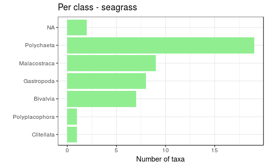

```r
## add the taxonomic classification to the 2 subsets of taxa per habitat
taxa.zostera.2012 <- left_join(taxa.zostera.2012, current.taxa.2012)
taxa.sand.2012 <- left_join(taxa.sand.2012, current.taxa.2012)
## number of taxa per class & habitat
# in seagrass
taxa.zostera.2012 %>%
  count(class, sort = TRUE) %>%
  ggplot(mapping = aes(x = reorder(class, n), y = n)) +
    geom_bar(stat = "identity", fill = "light green") +
    coord_flip() +
    labs(title = "Per class - seagrass", x = "", y = "Number of taxa") +
    theme_bw()
```

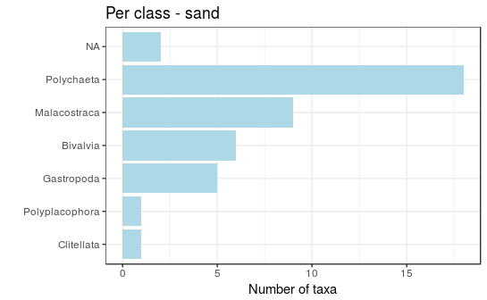

```r
# in sand
taxa.sand.2012 %>%
  count(class, sort = TRUE) %>%
  ggplot(mapping = aes(x = reorder(class, n), y = n)) +
    geom_bar(stat = "identity", fill = "light blue") +
    coord_flip() +
    labs(title = "Per class - sand", x = "", y = "Number of taxa") +
    theme_bw()
```

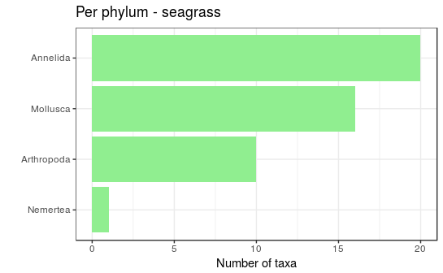

```r
## number of taxa per phylum & habitat
# in seagrass
taxa.zostera.2012 %>%
  count(phylum, sort = TRUE) %>%
  ggplot(mapping = aes(x = reorder(phylum, n), y = n)) +
    geom_bar(stat = "identity", fill = "light green") +
    coord_flip() +
    labs(title = "Per phylum - seagrass", x = "", y = "Number of taxa") +
    theme_bw()
```

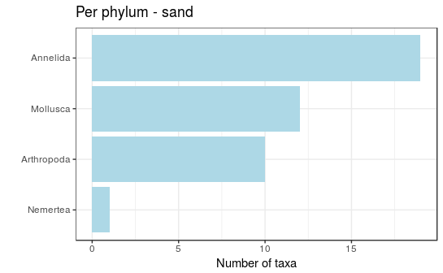

```r
# in sand
taxa.sand.2012 %>%
  count(phylum, sort = TRUE) %>%
  ggplot(mapping = aes(x = reorder(phylum, n), y = n)) +
    geom_bar(stat = "identity", fill = "light blue") +
    coord_flip() +
    labs(title = "Per phylum - sand", x = "", y = "Number of taxa") +
    theme_bw()
```

Count the number of species by taxonomic group and habitat.

```r
## in seagrass
taxa.zostera.2012 %>%
  count(group)
```

| group | n |
| --- | --- |
| Crustacea | 10 |
| Mollusca | 16 |
| Polychaeta | 19 |
| Varia | 2 |

```r
## in sand
taxa.sand.2012 %>%
  count(group)
```

| group | n |
| --- | --- |
| Crustacea | 10 |
| Mollusca | 12 |
| Polychaeta | 18 |
| Varia | 2 |

Now plot the number of taxa per (common) taxonomic group, and save as file.

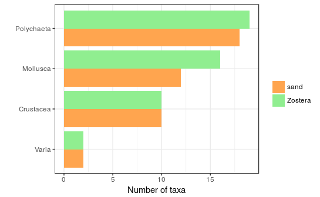

```r
nb.taxa.by.gr.habitat.2012 <- left_join(zoo.abnd.2012.long, current.taxa.2012) %>%
  group_by(habitat) %>%
  filter(sp_count > 0) %>%
  distinct(species, group) %>%
  count(group)
(plot.nb.taxa.by.gr.hab.2012 <- ggplot(nb.taxa.by.gr.habitat.2012, mapping = aes(x = reorder(group, n), y = n, fill = habitat)) +
    geom_bar(stat = "identity", position = "dodge") +
    scale_fill_manual(values=c("tan1", "light green"), name = "", labels = c("sand", "Zostera")) +
    coord_flip() +
    labs(x = "", y = "Number of taxa") +
    theme(axis.text.x = element_text(size = rel(1.3)),
          axis.text.y = element_text(size = rel(1.3))) +
    theme_bw()
)
ggsave(here::here(figures.dir, "nb_taxa_by_tax_group_2012.png"),
       plot.nb.taxa.by.gr.hab.2012,
       dpi = 300)
```

In the **seagrass** in Sozopol Bay (2012):  
+ **Crustacea** are represented by 9 families.  
+ **Polychaeta** are represented by 12 families.  
+ **Mollusca** are represented by 11 families.

The families with the highest number of species are:

```r
## in seagrass
lapply(setdiff(unique(taxa.zostera.2012$group), "Varia"),
       function(x) {
         taxa.zostera.2012 %>%
           group_by(group) %>%
           count(family) %>%
           filter(group == x) %>%
           arrange(desc(n))
       })
```

| group | family | n |
| --- | --- | --- |
| Mollusca | Rissoidae | 3 |
| Mollusca | Lucinidae | 2 |
| Mollusca | Semelidae | 2 |
| Mollusca | Veneridae | 2 |
| Mollusca | Cerithiidae | 1 |
| Mollusca | Lepidochitonidae | 1 |
| Mollusca | Mangeliidae | 1 |
| Mollusca | Muricidae | 1 |
| Mollusca | Mytilidae | 1 |
| Mollusca | Nassariidae | 1 |

[output cut: 1 more lines]

| group | family | n |
| --- | --- | --- |
| Crustacea | NA | 2 |
| Crustacea | Ampeliscidae | 1 |
| Crustacea | Aoridae | 1 |
| Crustacea | Atylidae | 1 |
| Crustacea | Balanidae | 1 |
| Crustacea | Corophiidae | 1 |
| Crustacea | Idoteidae | 1 |
| Crustacea | Upogebiidae | 1 |
| Crustacea | Varunidae | 1 |

| group | family | n |
| --- | --- | --- |
| Polychaeta | Capitellidae | 3 |
| Polychaeta | Maldanidae | 3 |
| Polychaeta | Syllidae | 3 |
| Polychaeta | Eunicidae | 2 |
| Polychaeta | Dorvilleidae | 1 |
| Polychaeta | Hesionidae | 1 |
| Polychaeta | Nereididae | 1 |
| Polychaeta | Paraonidae | 1 |
| Polychaeta | Pectinariidae | 1 |
| Polychaeta | Phyllodocidae | 1 |

[output cut: 2 more lines]

```
NA
```

In the **sands** in Sozopol Bay (2012):  
+ **Crustacea** are represented by 9 families.  
+ **Polychaeta** are represented by 13 families.  
+ **Mollusca** are represented by 11 families.

The families with the highest number of species are:

```r
## in sand
lapply(setdiff(unique(taxa.sand.2012$group), "Varia"),
       function(x) {
         taxa.sand.2012 %>%
           group_by(group) %>%
           count(family) %>%
           filter(group == x) %>%
           arrange(desc(n))
       })
```

| group | family | n |
| --- | --- | --- |
| Mollusca | Semelidae | 2 |
| Mollusca | Cardiidae | 1 |
| Mollusca | Cerithiidae | 1 |
| Mollusca | Hydrobiidae | 1 |
| Mollusca | Lepidochitonidae | 1 |
| Mollusca | Lucinidae | 1 |
| Mollusca | Mangeliidae | 1 |
| Mollusca | Muricidae | 1 |
| Mollusca | Mytilidae | 1 |
| Mollusca | Rissoidae | 1 |

[output cut: 1 more lines]

| group | family | n |
| --- | --- | --- |
| Crustacea | NA | 2 |
| Crustacea | Ampeliscidae | 1 |
| Crustacea | Aoridae | 1 |
| Crustacea | Atylidae | 1 |
| Crustacea | Balanidae | 1 |
| Crustacea | Cirolanidae | 1 |
| Crustacea | Corophiidae | 1 |
| Crustacea | Diogenidae | 1 |
| Crustacea | Upogebiidae | 1 |

| group | family | n |
| --- | --- | --- |
| Polychaeta | Spionidae | 3 |
| Polychaeta | Capitellidae | 2 |
| Polychaeta | Maldanidae | 2 |
| Polychaeta | Syllidae | 2 |
| Polychaeta | Ampharetidae | 1 |
| Polychaeta | Dorvilleidae | 1 |
| Polychaeta | Glyceridae | 1 |
| Polychaeta | Magelonidae | 1 |
| Polychaeta | Nephtyidae | 1 |
| Polychaeta | Nereididae | 1 |

[output cut: 3 more lines]

```
NA
```

Now let’s calculate the contribution of each taxonomic group to the **overall community composition by abundance**.

```r
## helper function to summarize taxonomic group contribution to abundance and biomass
summarize_tax_group_contr <- function(zoo.data, tax.data, key.col, value.col, ...) {
  # zoo.data - long data frame of count/biomass data
  # tax.data - data frame (wide) of taxonomic information on the same species
  # key.col - name of column to be used as key for joining the two data frames
  # value.col - name of column in zoo.data containing the values to be summarized

  value.col <- enquo(value.col)
  group.vars <- quos(...) # allow for multiple grouping variables
  zoo.data %>%
    left_join(tax.data, by = key.col) %>%
    group_by(!!!group.vars) %>%
    summarise(total := sum(!!value.col)) %>%
    mutate(proportion = total / sum(total))
}
zoo.abnd.2012.long %>%
  summarize_tax_group_contr(current.taxa.2012,
                            key.col = "species",
                            value.col = sp_count,
                            habitat, group) %>%
  arrange(habitat, desc(proportion))
```

| habitat | group | total | proportion |
| --- | --- | --- | --- |
| S | Mollusca | 507 | 0.40821256 |
| S | Polychaeta | 349 | 0.28099839 |
| S | Varia | 327 | 0.26328502 |
| S | Crustacea | 59 | 0.04750403 |
| Z | Mollusca | 2146 | 0.75457103 |
| Z | Varia | 323 | 0.11357243 |
| Z | Polychaeta | 292 | 0.10267229 |
| Z | Crustacea | 83 | 0.02918425 |

Now calculate and plot the **contribution of the taxonomic groups to the abundance by station and habitat** in Sozopol Bay in 2012.

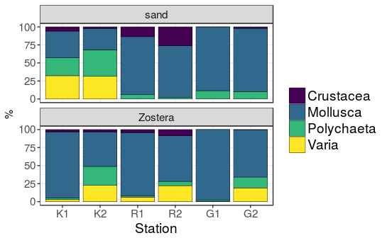

```r
tax.props.st.hab.2012 <- zoo.abnd.2012.long %>%
  summarize_tax_group_contr(current.taxa.2012,
                            key.col = "species",
                            value.col = sp_count,
                            habitat, station, group) %>%
  arrange(habitat, station)
(plot.tax.props.st.hab.2012 <- ggplot(tax.props.st.hab.2012) +
    geom_bar(mapping = aes(x = station,
                           y = proportion * 100,
                           fill = group),
             color = "black", size = 0.15,
             stat = "identity", position = "stack", inherit.aes = TRUE) +
    scale_fill_viridis(option = "viridis", discrete = TRUE, name = "") +
    scale_x_discrete(labels = c("K1", "K2", "R1", "R2", "G1", "G2")) +
    labs(x = "Station", y = "%") +
    # change the strip labels
    facet_wrap(~habitat, nrow = 2, labeller = as_labeller(c("S" = "sand", "Z" = "Zostera"))) +
    text_size(text.x = rel(1.3), text.y = rel(1.3), title.x = rel(1.3), legend.text = rel(1.3), strip.x = rel(1.3))
)
## save as file
ggsave(here::here(figures.dir, "tax_gr_props_st_hab_2012.png"),
       plot.tax.props.st.hab.2012,
       dpi = 300)
```

…and the **contribution of the taxonomic groups to the abundance by site & habitat**:

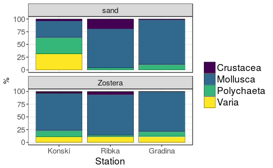

```r
tax.props.site.hab.2012 <- zoo.abnd.2012.long %>%
  summarize_tax_group_contr(current.taxa.2012,
                            key.col = "species",
                            value.col = sp_count,
                            habitat, site, group) %>%
  arrange(habitat, site)
(plot.tax.props.site.hab.2012 <- ggplot(tax.props.site.hab.2012) +
    geom_bar(mapping = aes(x = site,
                           y = proportion * 100,
                           fill = group),
             color = "black", size = 0.15,
             stat = "identity", position = "stack", inherit.aes = TRUE) +
    scale_fill_viridis(option = "viridis", discrete = TRUE, name = "") +
    # scale_x_discrete(labels = c("Konski", "Ribka", "Gradina")) +
    labs(x = "Station", y = "%") +
    # change the strip labels
    facet_wrap(~habitat, nrow = 2, labeller = as_labeller(c("S" = "sand", "Z" = "Zostera"))) +
    text_size(text.x = rel(1.3), text.y = rel(1.3), title.x = rel(1.3), legend.text = rel(1.3), strip.x = rel(1.3))
)
## save as file
ggsave(here::here(figures.dir, "tax_gr_props_site_hab_2012.png"),
       plot.tax.props.site.hab.2012,
       dpi = 300)
```

FIX FROM HERE!!!

Check and plot the species which contribute the most to the abundance at each habitat & station.

```r
top20.counts.2012.st <- get_top_sp(zoo.abnd.2012.long, nb.sp = 20, species.col = species, value.col = sp_count, habitat, station)
```

```
Error in match(x, table, nomatch = 0L) :
  'match' requires vector arguments
```

Now let’s calculate the same way the **overall community composition by biomass** in both habitat types in Sozopol Bay (2012).

```r
zoo.biomass.2012.long %>%
  summarize_tax_group_contr(current.taxa.2012,
                            key.col = "species",
                            value.col = sp_biomass,
                            habitat, group) %>%
  arrange(habitat, desc(proportion))
```

Then calculate and plot the **contribution of the taxonomic groups to the biomass by station and year** in Sozopol Bay.

```r
tax.props.biomass.st.yr.2012 <- zoo.biomass.2012.long %>%
  summarize_tax_group_contr(current.taxa.2012,
                            key.col = "species",
                            value.col = sp_biomass,
                            habitat, station, group) %>%
  arrange(habitat, station)

# plot this
(plot.tax.props.biomass.st.yr.2012 <- plot_tax_props(tax.props.biomass.st.yr.2012, x.labels = c("K1", "K2", "R1", "R2", "G1", "G2")) +
    facet_wrap(~habitat, nrow = 2, labeller = as_labeller(c("S" = "sand", "Z" = "Zostera"))) +
    text_size(text.x = rel(1.3), text.y = rel(1.3), title.x = rel(1.3), legend.text = rel(1.3), strip.x = rel(1.3))
)

## save as file
ggsave(here::here(figures.dir, "tax_gr_props_biomass_st_yr_2012.png"),
       plot.tax.props.biomass.st.yr.2012,
       dpi = 300)
```

Combine the proportions of the abundance and the biomass in one single plot.

```r
## combine the proportional abundance and biomass tibbles into a single common (long) one
tax.props.2012.all <- full_join(tax.props.st.yr.2012,
                                tax.props.biomass.st.yr.2012,
                                by = c("habitat", "station", "group")) %>%
  select(-starts_with("total")) %>%
  gather(key = variable, value = proportion, -habitat, -station, -group) %>%
  ungroup() %>%
  # fix a little the variables that will serve for faceting the plot, to avoid re-labeling later
  mutate(variable = case_when(variable == "proportion.x" ~ "Abundance",
                              variable == "proportion.y" ~ "Biomass"),
         habitat = case_when(habitat == "S" ~ "sand",
                             habitat == "Z" ~ "Zostera"))


(plot.composite.tax.gr.props.2012 <- plot_tax_props(tax.props.2012.all, x.labels = c("K1", "K2", "R1", "R2", "G1", "G2")) +
    facet_grid(habitat ~ variable) +
    theme(legend.position = "top", legend.key.size = unit(0.5, "cm")) +
    text_size(text.x = rel(1.2), text.y = rel(1), title.x = rel(1.2), legend.text = rel(1), strip.x = rel(1.2), strip.y = rel(1.2))
)

ggsave(here::here(figures.dir, "tax_gr_props_2012_composite.png"),
       plot.composite.tax.gr.props.2012,
       dpi = 300, width = 15, units = "cm")
```

Check and plot the species which contribute the most to the biomass at each habitat & station.

```r
## calculate the total biomass counts by species, then select the 20 with the highest biomass
top20.biomass.2012.st <- get_top_sp(zoo.biomass.2012, nb.sp = 20)

## plot them
plot.highest.biomass.sp.2012 <- plot_top_n(top20.biomass.2012.st,
                                     aes(x = species, y = log_y_min(sp_count),
                                         colour = station),
                                     labs.legend = c("K1", "K2", "R1", "R2", "G1", "G2"),
                                     lab.y = "Biomass (log(y/min + 1))",
                                     palette = "Set2"
                                     )

(plot.highest.biomass.sp.2012 <- plot.highest.biomass.sp.2012  +
    facet_wrap(~habitat, ncol = 2, labeller = as_labeller(c("S" = "sand", "Z" = "Zostera"))) +
    text_size(text.x = rel(1.2), strip.x = rel(1.1), text.y = rel(1), legend.text = rel(0.9)) +
    theme(legend.position = "top", legend.box.spacing = unit(0.01, "cm"), legend.direction = "horizontal") +
    guides(colour = guide_legend(nrow = 1)) +
    scale_x_discrete(name = "", limits = rev(levels(top20.biomass.2012.st$species)))
)

## save as file
ggsave(here::here(figures.dir, "highest_biomass_sp_st_2012.png"),
       plot.highest.biomass.sp.2012,
       dpi = 300, width = 15, units = "cm")
```

3. Site-level comparison of macrobenthic community composition & structure - seagrass/sand, Sozopol Bay, 2012

On second thought, for 2012, a more useful approach would be to 1) test whether there are differences in community composition between the pairs of stations at each of the 3 sites, in sand/seagrass - hopefully no; 2) find the top-contributing species to the abundance/biomass at the site level.

Check if the community composition differs between sites (using package mvabund for fitting GLMs).

```r
library(mvabund)

## convert the abundance tibble to matrix
zoo.abnd.2012.mat <- mvabund(zoo.abnd.2012 %>% arrange(habitat) %>% select(-c(station:replicate)))

## get the sites & habitats
sites.2012 <- (zoo.abnd.2012 %>%
  mutate(site = str_extract(station, "[^\\d]+")) %>%
  arrange(habitat))$site

habitats.2012 <- sort(zoo.abnd.2012$habitat)

## check the mean-variance relationship in the dataset - for some reason RStudio doesn't want to plot this today - sth to do with graphical device size.
meanvar.plot(zoo.abnd.2012.mat)
```

Fit the model & check the fit.

```r
## fit the model: do site + habitat influence community composition?
comm.diff.2012.mod <- manyglm(zoo.abnd.2012.mat ~ sites.2012 * habitats.2012, family = "negative.binomial")

## plot resiudals to check model fit
plot(comm.diff.2012.mod)

## check significance of results
comm.diff.2012.mod.summary <- anova(comm.diff.2012.mod, p.uni = "adjusted")
comm.diff.2012.mod.summary
```

```r
comm.diff.2012.st <- manyglm(zoo.abnd.2012.mat ~ stations.2012 * habitats.2012, famiily = "negative.binomial")

plot(comm.diff.2012.st)

comm.diff.2012.st.summary <- anova(comm.diff.2012.st, p.uni = "adjusted", block = sites.2012)
comm.diff.2012.st.summary
```

NB Save the models & summaries as R data objects, because they take way too much time to repeat.

```r
## community difference between sites & habitats
write_rds(comm.diff.2012.mod, here::here(save.dir, "comm_diff_model_2012.RDS"))

write_rds(comm.diff.2012.mod.summary, here::here(save.dir, "comm_diff_model_2012_summary.RDS"))

## community difference between stations & habitats within each site
write_rds(comm.diff.2012.st, here::here(save.dir, "comm_diff_st_model_2012.RDS"))

write_rds(comm.diff.2012.st.summary, here::here(save.dir, "comm_diff_st_model_2012_summary.RDS"))
```

Will go back and repeat all summaries, etc. at the *site level*, and put this quick analysis at the beginning of the 2012 section in the text to justify doing this. I’ll still keep the graphs, tables,.. with the analyses at the station level as they are heere to show my reasoning.  
All the 2012 community structure & biodiversity analyses will be moved to a separate notebook, because this is getting too long, and the workspace is filling up with objects.